# Phân Tích Lượng Người Dùng Internet trong Trận Đấu Bóng Rổ 2024 (Shinshu Brave Warriors vs. Nagasaki Velca)

# Mục tiêu Phân tích

1.Xác định thời điểm tương tác cao điểm:

Phân tích sự biến động của lưu lượng truy cập và hoạt động mạng xã hội theo thời gian, đặc biệt là vào các thời điểm trước trận đấu, trong khi trận đấu diễn ra (ví dụ: giờ nghỉ giữa hiệp, cuối trận), và ngay sau trận đấu.

Nhận diện các "khoảnh khắc vàng" (peak engagement moments) thu hút sự chú ý lớn từ cộng đồng mạng.

2.So sánh hành vi giữa hai ngày thi đấu:

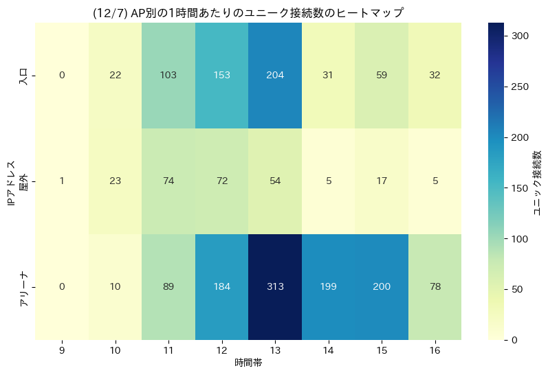

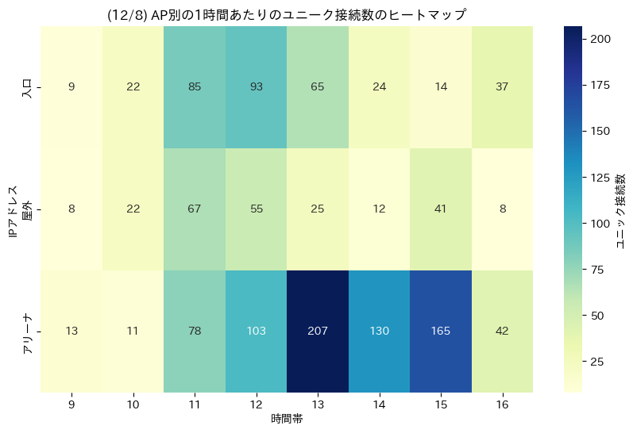

Vào ngày 8 tháng 12, lượng kết nối Internet đạt đỉnh cao điểm vào 13:00 (1 giờ chiều), với 207 kết nối duy nhất tại khu vực Arena. Mặc dù tổng thể có phần thấp hơn so với ngày 7 tháng 12 (đỉnh 313), ngày 8 vẫn cho thấy xu hướng tăng dần vào buổi sáng và duy trì hoạt động đáng kể đến giữa buổi chiều (với 165 kết nối tại Arena vào 15:00), gợi ý một sự kiện có thể kéo dài hoặc có các hoạt động liên tục.

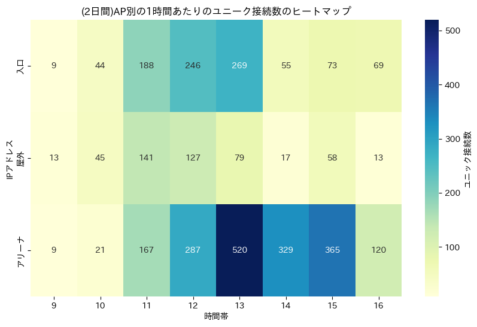

# Summary:

Cả hai ngày đều cho thấy mô hình tương tác cao điểm tương tự nhau, tập trung vào 13:00 (1 giờ chiều), đặc biệt là tại khu vực Arena. Điều này nhất quán với việc các hoạt động chính (ví dụ: trận đấu bóng rổ) diễn ra vào buổi chiều, thu hút lượng lớn người dùng kết nối cùng lúc.

Về tổng thể, trong hai ngày này, có 817 lượt kết nối duy nhất được ghi nhận. Khi tổng hợp và loại bỏ trùng lặp, có 620 người dùng (hoặc thiết bị) là hoàn toàn duy nhất đã truy cập Internet. Đặc biệt, đáng chú ý là có tới 197 người dùng duy nhất đã kết nối và sử dụng Wi-Fi trong CẢ HAI NGÀY. Con số này nhấn mạnh tỷ lệ khán giả trung thành và tương tác liên tục khá cao, cho thấy sự kiện có khả năng giữ chân người hâm mộ và khuyến khích họ quay lại tham gia vào các ngày khác nhau.